# 实验三 参数估计&非参数估计

- 姓名：马永田
- 学号：2012911
- 专业：计算机科学与技术专业

## 实验要求

### 截止日期：11月4日实验课之前

- 以.ipynb形式的文件提交，输出运行结果，并确保自己的代码能够正确运行
- 发送到邮箱：2120220594@mail.nankai.edu.cn

### 基本要求

生成两个各包含 N=1200 个二维随机向量的数据集合 X1 和 X2 ，数据集合中随机向量来自于三个分布模型，分别满足均值向量 μ1=[1,4] , μ2=[4,1] , μ3=[8,4] 和协方差矩阵 D1=D2=D3=2**I** ，其中**I**是2∗2的单位矩阵。在生成数据集合 X1 时，假设来自三个分布模型的先验概率相同 ；而在生成数据集合 X2 时，先验概率如下： p(w1)=0.6 , p(w2)=0.1 , p(w3)=0.3

1. 在两个数据集合上分别应用“似然率测试规则” 、“最大后验概率规则” 进行分类实验，计算分类错误率，分析实验结果。
2. 在两个数据集合上分别应用 h=1 时的方窗核函数或高斯核函数估计方法，应用“似然率测试规则”进行分类实验，计算分类错误率，分析实验结果。

### 中级要求

1. 根据初级要求中使用的一个核函数，在数据集 X2 上应用交叉验证法，在 h∈[0.1,0.5,1,1.5,2] 中寻找最优的h值。

### 高级要求

1. 任选一个数据集，在该数据集上应用k-近邻概率密度估计，任选3个k值输出概率密度分布图。

## 实验流程

### 基本要求

1. 在两个数据集合上分别应用“似然率测试规则” 、“最大后验概率规则” 进行分类实验，计算分类错误率，分析实验结果。
2. 在两个数据集合上分别应用 h=1 时的方窗核函数或高斯核函数估计方法，应用“似然率测试规则”进行分类实验，计算分类错误率，分析实验结果。 #### 生成数据集

```python
# 导入要用到的包
import numpy as np
import sys
import math
import matplotlib.pyplot as plt
from mpl_toolkits.mplot3d import Axes3D
```

```python
# 生成正态分布数据
def Generate_Sample_Gaussian(mean, cov, P, label):
    '''
        mean 为均值向量
        cov 为方差矩阵a
        P 为单个类的先验概率
        return 单个类的数据集
    '''
    # round(x[,n=0]) 保留到几位小数
    temp_num = round(1200 * P)

    # 生成一个多元正态分布矩阵
    x, y = np.random.multivariate_normal(mean, cov, temp_num).T

    #x,y坐标，x和y矩阵均符合正态分布
    #z表示每个点属于哪一类
    z = np.ones(temp_num) * label
    X = np.array([x, y, z])

     #X.T中每个元素都是有三个元素的列表，分别表示x值，y值，以及对应的标签
    return X.T
```

```python
def Generate_DataSet_plot(mean, cov, P):
    # 画出不同先验对应的散点图
    xx = []
    label = 1
    # 将xx变为包含三类数据的数据集
    for i in range(3):
        xx.append(Generate_Sample_Gaussian(mean[i], cov, P[i], label))
        label += 1
        i = i + 1
    #在这时xx是一个有三个元素的列表，每个元素都是一个类
    # 画图
    plt.figure()


    for i in range(3):
        #画出每类的样本向量(x,y)
        plt.plot(xx[i][:, 0], xx[i][:, 1], '.', markersize=4.)
        #画出每类的中心点(均值向量对应的点)
        plt.plot(mean[i][0], mean[i][1], 'r*')
    plt.show()
    return xx
```

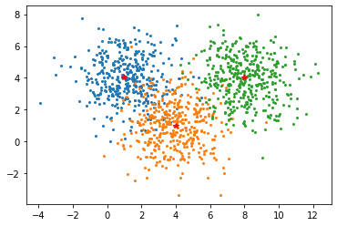

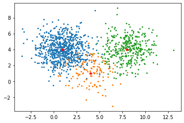

```
((1200, 3), (1200, 3))
```

```python
mean = np.array([[1, 4], [4, 1], [8, 4]])  # 均值数组
cov = [[2, 0], [0, 2]]  # 方差矩阵
num = 1200  # 样本个数
P1 = [1 / 3, 1 / 3, 1 / 3]  # 样本X1的先验概率
P2 = [0.6, 0.1, 0.3]  # 样本X2的先验概率
X1 = np.array(Generate_DataSet_plot(mean, cov, P1), dtype=object)
X2 = np.array(Generate_DataSet_plot(mean, cov, P2), dtype=object)
X1 = np.vstack(X1)
X2 = np.vstack(X2)
X1.shape, X2.shape  # 前两列是坐标，最后一列是标签
```

#### 参数估计

在两个数据集合上分别应用“似然率测试规则” 、“最大后验概率规则” 进行分类实验，计算分类错误率，分析实验结果。

```python
def Gaussian_function(x, mean, cov):
    det_cov = np.linalg.det(cov)  # 计算方差矩阵的行列式
    inv_cov = np.linalg.inv(cov)  # 计算方差矩阵的逆
    #计算概率p(x|w)
    p = 1/(2*np.pi*np.sqrt(det_cov))*np.exp(-0.5 *
    np.dot(np.dot((x - mean),inv_cov), (x - mean)))
    return p
```

```python
# 似然率测试规则
def Likelihood_Test_Rule(X, mean, cov):
    class_num = mean.shape[0]  # 类的个数
    num = np.array(X).shape[0]
    error_rate = 0
    for i in range(num):
        p_temp = np.zeros(3)
        for j in range(class_num):
        	# 计算样本i决策到j类的概率
            p_temp[j] = Gaussian_function(X[i][0:2], mean[j], cov)
        p_class = np.argmax(p_temp) + 1  # 得到样本i决策到的类
        if p_class != X[i][2]:
            error_rate += 1
    return round(error_rate / num , 3)
```

```python
##最大后验概率规则
def Max_Posterior_Rule(X, mean, cov, P):
    class_num = mean.shape[0]  # 类的个数
    num = np.array(X).shape[0]
    error_rate = 0
    for i in range(num):
        p_temp = np.zeros(3)
        for j in range(class_num):
        	# 计算样本i是j类的后验概率
            p_temp[j] =Gaussian_function(X[i][0:2],mean[j],cov)*P[j]
        p_class = np.argmax(p_temp) + 1  # 得到样本i分到的类
        if p_class != X[i][2]:
            error_rate += 1
    return round(error_rate / num,3)
```

```python
# 单次试验求不同准则下的分类误差
def repeated_trials(mean, cov, P1, P2, X1, X2):
    # 根据mean，cov，P1,P2生成数据集X1,X2
    # 通过不同规则得到不同分类错误率并返回
    error = np.zeros((2, 2))
    # 计算似然率测试规则误差
    error_likelihood = Likelihood_Test_Rule(X1, mean, cov)
    error_likelihood_2 = Likelihood_Test_Rule(X2, mean, cov)
    error[0] = [error_likelihood, error_likelihood_2]
    # 计算最大后验概率规则误差
    error_Max_Posterior_Rule = Max_Posterior_Rule(X1, mean, cov, P1)
    error_Max_Posterior_Rule_2 = Max_Posterior_Rule(X2, mean, cov, P2)
    error[1] = [error_Max_Posterior_Rule, error_Max_Posterior_Rule_2]
    return error
```

```python
#计算误差
error = repeated_trials(mean, cov, P1, P2, X1, X2)
print("data\tLikelihood_Test_Rule\tMax_Posterior_Rule")
print("X1\t", error[0][0], "\t\t\t", error[1][0])
print("X2\t", error[0][1], "\t\t\t", error[1][1])
```

```
data	Likelihood_Test_Rule	Max_Posterior_Rule
X1	 0.072 			 0.072
X2	 0.067 			 0.047
```

**实验结果分析：**

- 不同类别的先验概率P相同时(即数据集X1)，似然率测试规则和最大后验概率规则的分类结果相同
- 当先验概率相差较大时(即数据集X2)，最大后验测试规则更好一些

#### 非参数估计

在两个数据集合上分别应用 h=1 时的方窗核函数或高斯核函数估计方法，应用“似然率测试规则”进行分类实验，计算分类错误率，分析实验结果。

```python
# Hint for 初级要求：高斯核概率密度函数计算
# 在公式中，x和mean应该是列向量，但是为了方便，这里接收的都是行向量（维度：1*2）
def Gaussian_Kernel(x, X, h=2):
    # 计算概率p(x|w)
    #print(np.array(x).shape,np.array(X).shape)
    p = (1 / (np.sqrt(2 * np.pi) * h)) * np.array([np.exp(-0.5 * np.dot(x - X[i][0:2], x - X[i][0:2]) / (h**2)) for i in range(len(X))]).mean()
    return p
```

```python
# 高斯核函数 似然率测试规则
def LikelihoodTest_GaussKernel(X, h=1.0):
    error_rate = 0
    num = X.shape[0]
    w = [[]for i in range(3)]
    for item in X:
        if item[2] == 1:
            w[0].append(item)
        elif item[2] == 2:
            w[1].append(item)
        elif item[2] == 3:
            w[2].append(item)
    for i in range(num):
        p_temp = np.zeros(3)
        for j in range(3):
            p_temp[j] = Gaussian_Kernel(X[i][0:2], w[j], h)
        p_class = np.argmax(p_temp) + 1
        if p_class != X[i][2]:
            error_rate += 1
    return round(error_rate / num, 3)
```

```python
error_kernel = np.zeros((2))
error_kernel[0] = LikelihoodTest_GaussKernel(X1)
error_kernel[1] = LikelihoodTest_GaussKernel(X2)
print("Data\t X1\t X2")
print("Error\t", error_kernel[0], "\t", error_kernel[1])
```

```
Data	 X1	 X2
Error	 0.069 	 0.071
```

**实验结果分析：** 使用高斯核函数估计方法，应用似然率测试规则进行非参数估计，实验中进行多次估计，发现其结果不同于参数估计，在X1与X2两个数据集上的估计结果不存在明显的优劣差别。分析原因是参数估计不假定数学模型，可避免对总体分布的假定不当导致重大错误，所以常有较好的稳健性。